# Build-a-model

Lorenzo Menichetti

2024-11-06

# 1 Introduction

This brief tutorial aims at teaching you how to build a compartmental decomposition model.  
The only prerequisites are:  
1) Know how to use an R script (executing it)  
2) Know how to use copy-paste  
3) Know roughly what we are talking about with organic matter decomposition (I mean, that organic matter decomposes)

We will rely on differential equations.  
This might sound scary, if you don’t like maths, but computers have a lot of tricks to help you. A differential equation is extremely intuitive to read and write… it is just very difficult to solve. But we don’t need to do that, the computer will do it for us.  
The tutorial is written in extremely blunt and simple (maybe simplistic, sometimes) form.

**The tutorial is all based on copy-paste.**  
Your main task is to copy the code chunks you see here into an R script of your own and then run it step by step.  
Play with it as much as you can, see what happens.  
We will then discuss it together.

# 2 Installing a functional R environment

## 2.1 Installing R

[figure not shown]

We are going to rely on the statistical framework R, and you need to install it on your machine. You can find the installation files here: [ https://www.r-project.org/] (https://www.r-project.org/) And it should be running on any OS, just select the appropriate file. We will assume here you can already install software.

# 3 Installing RStudio

R is a relatively bare environment that relies on command line inputs and any note editing software to craft your scripts. You can simplify your work using a specific integrated development enviroment, quite popular nowadays, RStudio:  
[https://www.rstudio.com/products/rstudio/] (https://www.rstudio.com/products/rstudio/)

RStudio has four panels, and you work mainly in the first one after you have created a new R script file:

[figure not shown]

The other panels are useful, and the most important is the console, which is where your script “communicates” with R and where all the commands are run.

[figure not shown]

You can select a chunk of code from your script, and when it is selected press “CTRL+Enter”, and this will run the selected code (line by line) in the console.  
You will probably create new objects, which you will see in the “Environment” tab in the panels up right.  
The lower right panel is mainly for visualizing plots and for visualizing the files in your working folder.

### 3.0.1 Set up correctly your working directory!

Which reminds us: **set up your working directory!**  
R works within a certain folder, for example reading and writing files there. The easiest way to deal with it for a beginner is to work always in the same folder where your script is:

[figure not shown]

You can check what is your working directory writing in the console:

```r
getwd()
```

```
## [1] "/Users/ilmenichetti/Library/CloudStorage/OneDrive-Valtion(2)/Teaching/Agroforestry/build_a_model"
```

(and pressing then enter… here you see the working folder I am working with when writing this tutorial) Ok, now you are more or less familiar with the technicalities, let’s build our model.

# 4 An ODE solver?

## 4.1 ODEs

# 5 Defining the ODE (= building the model)

## 5.1 The simplest possible compartmental model: the exponential model

This is the important part, here you are building your model. All the rest are just technicalities.  
We are going to describe the decomposition of a mass of organic carbon $C_0$ (carbon at time $0$) over time. Every instant we have a fraction of that carbon $k$ that decomposes, because microbes eat part of it (so the bigger the mass you have, the more C is going to leave it per unit of time). We can write it in differential form as:

$C'= C \cdot -k$

or if you prefer:

$\frac{dC}{dt} = C \cdot -k$

## 5.2 The exponential decomposition model solved for time

This equation becomes, when solved for time ($t$), becomes:

$C_t = C_0 \cdot e^{-k \cdot t}$

Which describes the evolution of the Carbon with time ($C_t$). It is an exponential function, rather common in nature. But for now skip the solution, because we won’t need it here, and the approach you will learn is more general than that because you will be able to apply it to any ODE, and specifically will allow you to build rather complex compartmental decomposition models easily.  
As you might already know from other sources, it is a rather common approach for organic matter decomposition models to use this type of equations (exponential). In most cases they use more than one single comparment, including also the fluxes between them, but all compartments decompose with an exponential function. This function, as simple as it is, does a surprisingly good job in describing what happens in nature when organic matter decomposes.

# 6 Writing the ODE in R and using a solver

## 6.1 Writing the function for our solver to use

We need to write the ODE in a form that R can digest. We will use the package `deSolve` as solver. To use it, we first need to define our ODE into an own function:

```r
exp_diff<-function(Time, State, Pars) { #this is how you define your own functions
  #in R, () are the inputs to the function and {} is the function.
  # the operator <- stores the results in the object you declare at its right
  with(as.list(c(State, Pars)), {
    C    <- C*-k # THIS LINE HERE IS YOUR MODEL, the rest does not matter
    return(list(c(C))) #this line is to make the function return the results
  })
}
```

The function is written in order to be generic, so that you can just change your ODE (or system of ODEs) and it would still work.

We then define the time over which we want to solve our equation (`Time`), the initial state of the system (`State`, in this case for only one variable C), and the parameters (`Pars`, in this case only $k$):

```r
Time <- seq(0, 20, by = 1) #a sequence of numbers from 0 to 20 time steps
State <- c(C=80) #we need to give all the states as a vector of states, with c()
#the vector elements are inside the parenthesis (only one in this case)
Pars <- c(k=0.15) #as above
```

## 6.2 Running the solver

We then proceed to run our ODE solver like this, with the function `ode`:

```r
library(deSolve)

exp_diff<-function(Time, State, Pars) {
  with(as.list(c(State, Pars)), {
    C    <- C*-k
    return(list(c(C)))
  })
}

Time <- seq(0, 20, by = 1)
State <- c(C=80)
Pars <- c(k=0.15)

output   <- ode(State, Time, exp_diff, Pars)
```

(if you are curious about the syntax of an R function, remember you can just write `?ode` in the console and press enter)

Done. The solver finds the solution and provides to calculate it for the time vector we provided (in this case a sequence from 0 to 20, let’s say years).  
It stores the results in the object `output`:

```r
output
```

```
##    time         C
## 1     0 80.000000
## 2     1 68.856704
## 3     2 59.265533
## 4     3 51.010288
## 5     4 43.904956
## 6     5 37.789327
## 7     6 32.525593
## 8     7 27.995048
## 9     8 24.095564
## 10    9 20.739245
## 11   10 17.850435
## 12   11 15.364013
## 13   12 13.223930
## 14   13 11.381939
## 15   14  9.796525
## 16   15  8.431947
## 17   16  7.257444
## 18   17  6.246540
## 19   18  5.376446
## 20   19  4.627550
## 21   20  3.982969
```

## 6.3 See what we’ve done?

We can plot the output with:

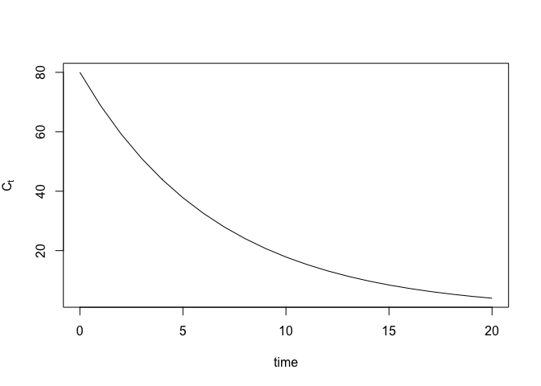

```r
plot(output[,1], output[,2], type="l", xlab="time", ylab=expression(paste(C[t])))
```

# 7 Encapsulating the ODE and the solver into a function we can calibrate

To “calibrate” means we are going to try to find the parameter combination that minimize the error of the model relatively to our target data. In order to do this, we need to write down a function that as output gives the fitness of the solved ODE system with a certain parameter (which we will then vary automatically, you will see later).

## 7.1 Writing a cost function

To do that such function should compare the output of our model with the measured data we are using for calibration.

**You will need a time series of measurements for optimizing your model. You can find the example here: Ultuna_LTBF_data.csv. Donwload it and put it in the same folder than your R script.** .  
In case you did not set up your home directory to this folder, remember that the following commands will not work (the `read.csv` command will not find the file and complain).

We will then encapsulate in this function the function we wrote above and the solver. The “cost” is a metric we want to minimize, usually some metric of model fitness.

```r
#reading the data we want to calibrate on
target_data<-read.csv("Ultuna_LTBF_data.csv")


#putting the data in the right place
Time <- target_data$BF_duration
State <- c(C=target_data$Mean_C.stock_t.ha[1])

library(Metrics) #to include the function to calculate the RMSE


exp_optim<-function(Time, State, Pars) {
  with(as.list(c(State, Pars)), {

    output   <- ode(State, Time, exp_diff, Pars) #here you are using the solver and the ODE function we wrote before
                                                 #to calculate a simulation with a certain paramter setup
    fitness  <- rmse(output, target_data$Mean_C.stock_t.ha) # here you are calculating the fitness of your model on the data

    return(fitness) #this function must return one single value as object
  })
}
```

## 7.2 Optimizing against measured data

We will optimize the function to represent a dataset measured from a real experiment, the Ultuna Long Term Bare Fallow. It is a patch of soil which is kept devoid from any organic inputs since the start of the experiment (1956), where we can see just the decomposition of the existing organic matter. It is a rather simple case that suits well our simple model. Let’s read and visualize the data first:

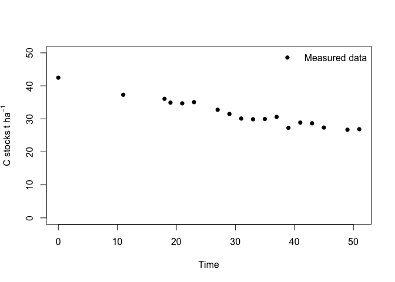

```r
#plotting the data
plot(target_data$BF_duration, target_data$Mean_C.stock_t.ha, ylim=c(0,50),
     ylab=expression(paste("C stocks t ",ha^-1)), xlab="Time", pch=16)
legend("topright", c("Measured data"), bty="n",
       pch=c(16), lty=c(NA), lwd=c(NA), col=c("black"))
```

# 8 Optimizing the function (A.K.A. calibrating)

We are now going forward and optimizing the function. In this case we are optimizing for one single parameter and we need to use the function `optimize`, much simpler than multi parameter optimizationa algorithms. One quirk of this particular function is the syntax, it needs to optimize a function that has as parameters only `x`, where `x` is the parameter of our objective function. We need therefore to write a small wrapper function like this:

```r
exp_optim_wrapper<-function(x){exp_optim(Time, State, Pars=c(k=x))}
```

We can then proceed with the optimization, storing the results in the object `opt_results`:

```r
opt_results<-optimize(exp_optim_wrapper,  lower = 0.01, upper = 1)

opt_results
```

```
## $minimum
## [1] 0.0100652
##
## $objective
## [1] 12.26911
```

The object contains two results, a `minimum`, which is the point where the optimized parameter gives the minimum cost (the RMSE in our case), and a `objective`, which is the minimum value reached by our cost (again the RMSE).

We now want to check our optimization, making a simulation with he new optimal value we just found.  
We first redefine the parameter of our simulation as the output from the optimization:

```r
Pars_opt<-c(k=opt_results$minimum)
```

## 8.1 Running the simulation with our new (set of) parameter(s)

And then proceed to run our model with it, storing the results in the object `simulation`:

```r
simulation<-as.data.frame(ode(State, Time, exp_diff, Pars_opt))

simulation
```

```
##    time        C
## 1     0 42.48000
## 2    11 38.02779
## 3    18 35.44070
## 4    19 35.08577
## 5    21 34.38654
## 6    23 33.70125
## 7    27 32.37136
## 8    29 31.72623
## 9    31 31.09395
## 10   33 30.47427
## 11   35 29.86695
## 12   37 29.27172
## 13   39 28.68836
## 14   41 28.11662
## 15   43 27.55628
## 16   45 27.00710
## 17   49 25.94137
## 18   51 25.42438
```

All seems well, and our function simulates a reasonable trend of SOC decomposition. Let’s try to plot it against the measurements:

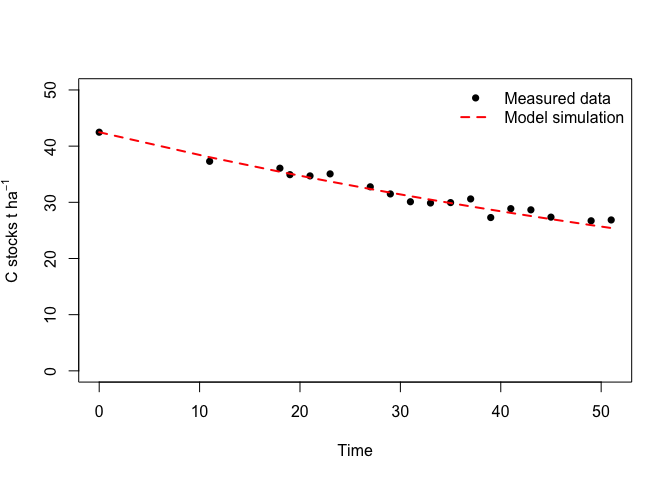

```r
#plotting the simulation against the data
plot(target_data$BF_duration, target_data$Mean_C.stock_t.ha, ylim=c(0,50),
     ylab=expression(paste("C stocks t ",ha^-1)), xlab="Time", pch=16)
lines(simulation$time, simulation$C, lty=2, lwd=2, col="red")
legend("topright", c("Measured data", "Model simulation"), bty="n",
       pch=c(16, NA), lty=c(NA, 2), lwd=c(NA, 2), col=c("black", "red"))
```

Our simulation seems to work pretty well!  
Congratulations, you just built and calibrated a model!